# Homework 4

# Submission Instructions

- Submit responses in a .ipynb file.
- For calculation questions:
  - Include R code used.
  - Ensure all code has been executed to display output.
  - Round *answers* to 3-5 decimal places if necessary.
  - Avoid unnecessary R outputs.
  - Support conclusions with plots when checking assumptions.
  - Assume $\alpha = 0.05$ and set any trimming to $20\%$ unless stated otherwise.
  - Do not use robust methods unless specified by the question.
  - Two-sided hypothesis tests require two-sided confidence intervals.
  - One-sided hypothesis tests require one-sided confidence intervals.

# Question 1

Some archaeologists theorize that ancient Egyptians interbred with several different immigrant populations over thousands of years. To see if there is any indication of changes in body structure that might have resulted, they measured 30 skulls of male Egyptians dated from 4000 B.C.E. and 30 others dated from 200 B.C.E. We will be using this data to conduct a classic independent t-test to compare the means of the two epochs.

- Thomson and Randall-Maciver, *Ancient Races of the Thebaid*, Oxford: Oxford University Press, 1905.

The data can be found in **“SkullsPartial.csv”**. The column “mb” measures the maximal breadth of the skull.

The data is in the “tidy format”. Find a way to calculate the means for both epochs, as well as the difference between the means. *No special packages are required for this*. You have already learned methods which can help you here.

# Question 2

Using the skull data, calculate the standard deviation and variance for both epochs.

# Question 3

Using the skull data, calculate the pooled variance.

# Question 4

Using the skull data, calculate the pooled standard error.

# Question 5

Calculate a two-sided 95% confidence interval for the difference in mean skull breadth between these two epochs. Use of `t.test()` is not permitted.

# Question 6

Test $H_0: \mu_{_\text{4000}} - \mu_{_\text{200}} = 0$.

Use of `t.test()` is not permitted.

Make sure to report:

- the test statistic
- p-value
- whether your reject or fail to reject the $H_0$

# Question 7

A researcher states their null hypothesis about the skull data as $H_0: \mu_{_\text{4000}} < \mu_{_\text{200}}$.

Another way of expressing this is by writing: $H_0: \mu_{_\text{4000}} - \mu_{_\text{200}} < 0$.

Given the null hypothesis being expressed, answer the following questions:

## a.

Is this a one or two-tailed hypothesis?

## b.

How would you interpret this hypothesis in plain English?

## c.

In which tail is the critical region located for this hypothesis?

## d.

Given what you said in “c.”, which direction should a p-value be calculated? *Left to right* OR *right to left*?

## e.

There are two other mathematically equivalent ways of writing the null hypothesis here. What are they? Your answer should take the form of “$H_0:$________”.

# Question 8

Test $H_0: \mu_{_\text{4000}} - \mu_{_\text{200}} < 0$ or an equivalent version of it. Report the p-value and 95% confidence interval, and state whether you reject the null hypothesis. Use of `t.test()` is not permitted.

# Question 9

Create a barplot of the means for the Skull data. Give each bar two-sided 95% confidence intervals as the errorbars. Have the y-axis go from 110 to 140.

# Question 10

Suppose that the summary stats of your groundbreaking research are . . .

$\bar{x}_1 = 15$

$\bar{x}_2 = 12$

$s^2_1 = 8$

$s^2_2 = 24$

$n_1 = 20$

$n_2 = 10$

Verify that $s^2_p = 13.14$, $T = 2.14$, and that a classic T-test rejects the null hypothesis of equal means with $\alpha = 0.05$. Compute a confidence interval for this hypothesis test.

# Question 11

Using the information from the previous question, plot the group means and their respective two-sided confidence intervals. Label the two groups A and B. The plot you create should match the plot below.

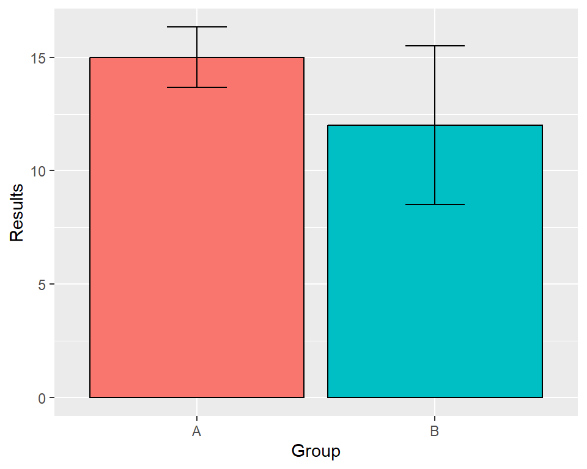

- Hint: To complete this task, you will need to create a dataframe containing the relevant values. Since we do not have access to the original dataset, you cannot rely on ggplot’s automated methods or the `summarise()` function to generate the necessary summaries. Instead, you must manually construct a dataframe that contains the aggregated values needed for ggplot. This process is actually simpler than it might seem—think back to our early lectures on working with dataframes in R.

# Question 12

What is a potentially serious problem for the results seen in the previous question (hint: compare the errorbars)?

# Question 13

Conduct a test that is designed to solve the **specific** problem noted by the previous question (the answer rhymes with ‘belch’). Do the conclusions change from what you got when you ran a classic t-test? Specify the name of the test you ran, its test statistic, degrees of freedom, p-value, and two-sided 95% confidence interval.

# Question 14

Responses to stress are governed, in part, by the hypothalamus. Imagine you have two groups of participants. The first shows signs of heart disease and the other does not. You want to determine whether the groups differ (in any direction) in terms of the weight of the hypothalamus.

Use the data “**heartDisease.csv**” on eClass to determine whether the groups differ based on a classic t-test. Use $\alpha = .05$. Use of `t.test()` is not permitted.

Make sure to report:

- the test statistic
- degrees of freedom
- p-value
- Confidence Interval
- Whether your reject or fail to reject the $H_0$

# Question 15

Compute an appropriate measure of effect size for the previous question. Use of `cohen.d()` is not permitted.

# Question 16

Repeat question 14, but use a Welch’s t-test. Use of `t.test()` is not permitted.

# Question 17

Plot the group means with their respective two-sided confidence intervals for the **heartDisease.csv** data.

# Question 18

Repeat question 14 using 20% Trimmed Means. Do you get a different conclusion? Use of `yuen()` is not permitted.

# Question 19

Plot the group trimmed means with their respective two-sided confidence intervals for the **heartDisease.csv** data using 20% trimming.

# Question 20

Generate Q-Q plots to assess the normality assumption of the **heartDisease.csv** data. Should a classic t-test be run on this data?

# Question 21

Generate boxplots to compare the two groups of the **heartDisease.csv** data. Make the boxplots pretty colours.